# MATH5741M: Statistical Theory and Methods Lecture 10

29 November, 2021  
Reminder to myself: start recording and let people out of the waiting room.

## Example

Clinical trials of medical treatments each have two possible outcomes:

- positive (the treatment is shown to be effective),
- negative (the treatment is not shown to be effective).

Let \(p\in (0,1)\) be the unknown proportion of positive trials.

Suppose that \(1000\) randomly selected, independent clinical trials have been reviewed, with the goal of estimating \(p\).

Let \(X\) be the total number of positive trials out of \(1000\) trials.

1. What is the distribution of \(X\)? What is its mass function?
2. Among the \(n = 1000\) reviewed trials, \(x = 250\) had a positive result. What is the maximum likelihood estimate of \(p\)? (Please go through the necessary steps to derive the formula for the MLE, don’t just write it down.)

## Example

\(X \sim \text{Bin}(n, p)\) with \(n = 1000\) and \(f(x) = {n\choose x}p^{x}(1-p)^{n-x}\).

We can think of \(x=250\) as a sample of size \(1\) from \(\text{Bin}(1000, p)\).

\(L(p) = {\mathsf P}(X = 250) = f(250)\)

\(\phantom{L(p)} = {1000 \choose 250}p^{250}(1-p)^{750}\\\)

\(\ell(p) = \log L(p)\)

\(\phantom{\ell(p)} = \log{1000 \choose 250} + \log p^{250} + \log(1-p)^{750}\)

\(\phantom{\ell(p)} = \log{1000 \choose 250} + 250\log p + 750\log(1-p)\\\)

\(\displaystyle \frac{d\ell}{dp} = 0 + 250\frac{1}{p} + 750\frac{-1}{1-p}\)

## Example

We need to solve \(\frac{d\ell}{dp} = 0\) for \(p\):

\(250\frac{1}{p} + 750\frac{-1}{1-p} = 0\)

\(\Leftrightarrow \quad 250(1-p) = 750p\)

\(\Leftrightarrow \quad p = 250/1000.\)

Therefore \(\widehat{p} = 0.25\) is our proposed MLE.

But does this really give a maximum?

\(\displaystyle \frac{d^2 \ell}{dp^2} = -\frac{250}{p^2} - \frac{750}{(1-p)^2} < 0.\)

So we take \(\widehat{p} = 0.25\) as our MLE.

## Example

What is meant by the term “posterior distribution”?

1. The sampling distribution of our maximum likelihood estimator, \(\widehat{p}\).
2. The estimated distribution of our variable, \(X \sim \text{Bin}(n, \widehat{p})\), obtained from our estimate \(\widehat{p}\).
3. The distribution that describes our subjective uncertainty about \(p\) after observing our sample.
4. At least two of the above are equivalent.

The answer is **3**.

When we apply Bayesian methods, we move away from ideas such as maximum likelihood estimation. We are not usually thinking about an estimator \(\widehat{p}\).

We think of \(p\) itself as being random. Each of us will assign a distribution to \(p\) that describes our own subjective uncertainty about the value of \(p\).

## Example

**My** beliefs about \(p\), **before** observing \(X\), are described by a prior distribution \[p \sim \textrm{Beta}(500, 500).\] Plot the density of this prior in R. Interpret my beliefs. Hint: `dbeta()` can calculate the densities.

```r
p <- seq(from = 0, to = 1, by = 0.01)
```

[output not shown]

```r
prior <- dbeta(p, shape1 = 500, shape2 = 500)
```

## Example

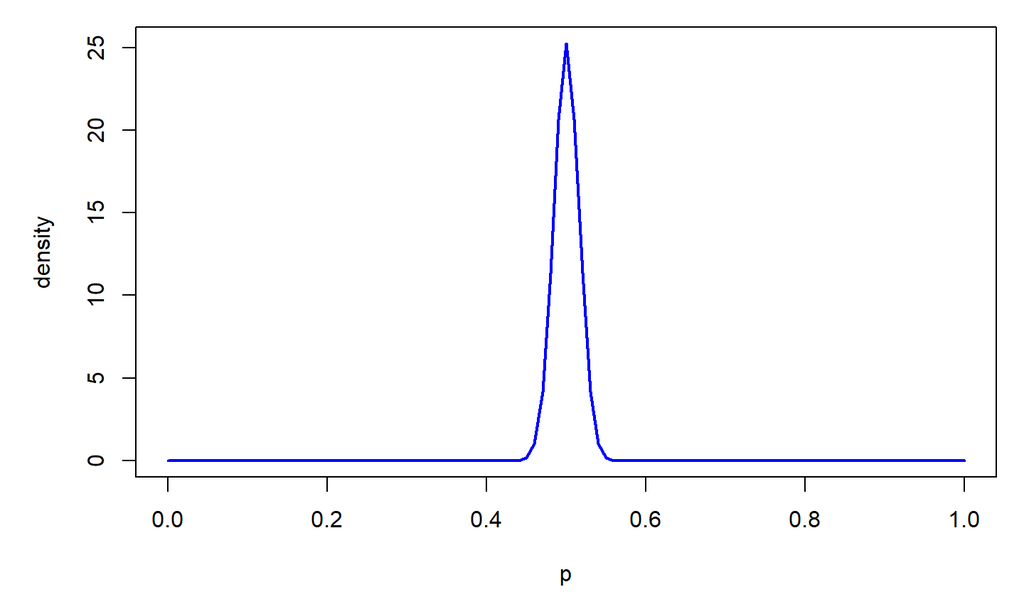

The prior density, which appears to be very high near \(p = 0.5\). This suggests that I believe \(p\) is very likely to be close to \(0.5\).

```r
plot(p, prior, type = "l", col = "blue", lwd = 2, ylab = "density")
```

## Example

Given that we observed \(X = 250\), how should I update my prior beliefs? Write down my posterior distribution for \(p\) and plot its density in R. Interpret my posterior beliefs.

## Example

My prior beliefs about \(p\) were described by a beta distribution:

\(f(p) \; \propto \; p^{\alpha-1}(1-p)^{\beta-1}\)

\(\phantom{f(p)} \; = \; p^{499}(1-p)^{499}.\)

We also need the likelihood of \(x = 250\):

\(f(x \mid p) \; = \; L(p)\)

\(\phantom{f(x \mid p)} \; = \; {1000 \choose 250}p^{250}(1-p)^{750}\)

\(\phantom{f(x \mid p)} \; \propto \; p^{250}(1-p)^{750}.\)

We should apply Bayes’ theorem (posterior \(\propto\) prior \(\times\) likelihood):

\(f(p \mid x) \; \propto \; f(p)f(x \mid p)\)

\(\phantom{f(p \mid x)} \; \propto \; p^{749}(1-p)^{1249}.\)

## Example

We should recognise this as \(p^{\alpha-1}(1-p)^{\beta-1}\) from the density of a beta distribution. We just need to work out the parameters.

\(f(p \mid x) \; \propto \; p^{749}(1-p)^{1249}\)

\(\phantom{f(p \mid x)} \; = \; p^{750-1}(1-p)^{1250-1}.\)

\(f(p \mid x)\) is therefore proportional to the density of \(\textrm{Beta}(750, 1250)\).

Since proportionality of density functions implies that they must be equal, this means that my posterior distribution for \(p\) must be \[p \mid X = 250 \quad \sim \quad \textrm{Beta}(750,1250).\]

## Example

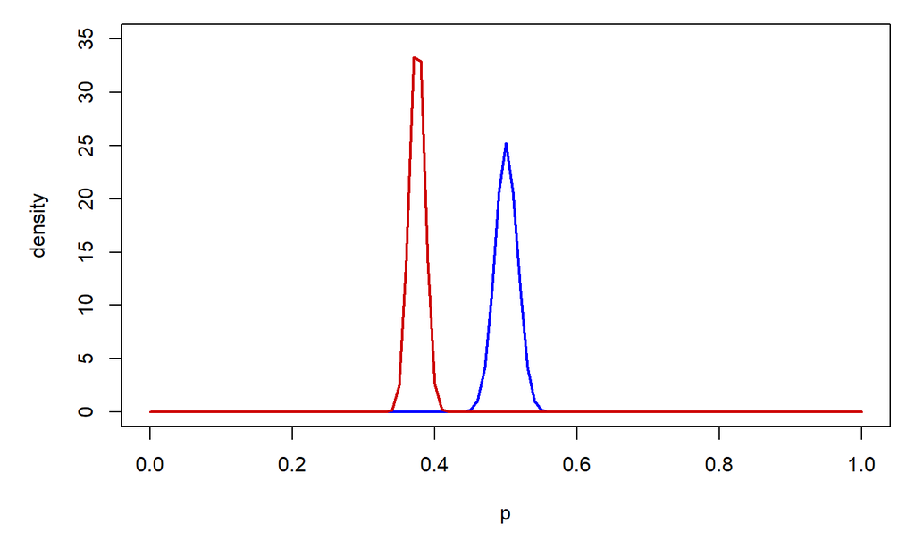

The prior density (blue) and posterior density (red). My posterior beliefs (sensibly) fall somewhere between my prior beliefs (\(p\approx 0.5\)) and the conclusion suggested by the data (\(p \approx 0.25\)). The posterior suggests that \(p\) is very likely to be around \(0.37\).

```r
posterior <- dbeta(p, shape1 = 750, shape2 = 1250)
lines(p, posterior, col = "red3", lwd = 2)
```

## Do you have any question or comments?

Over the holidays, please remember that you can still contact me if you need any help.

## Semester 2 modules

**MATH3092/MATH5092M: Mixed Models/Mixed Models with Medical Applications**

https://webprod3.leeds.ac.uk/catalogue/dynmodules.asp?Y=202122&M=MATH-5092M http://webprod3.leeds.ac.uk/catalogue/dynmodules.asp?Y=202021&M=MATH-3092

This module aims to introduce students to mixed models for the analysis of data with complex hierarchical or clustered structures. These models will be demonstrated through real-life examples from the medical, environmental and social sciences. More advanced models for clustered data with non-hierarchical structures, such as cross-classification and multiple membership, will be introduced through their applications in medical statistics. The optimal design of experiments with clustered data will be covered, with reference to clinical trials.

**MATH2775: Survival Analysis**

https://webprod3.leeds.ac.uk/catalogue/dynmodules.asp?Y=202122&M=MATH-2775

Survival analysis is concerned with data on how long it takes for a certain event to occur, such as: death of a patient after onset of a disease; breakdown of a home appliance after purchase; making a claim after taking out a car insurance policy; finding a job after graduation from university, etc. The appropriate statistical methods to analyse and model survival data are of critical importance in medical studies and actuarial work, as well as in other settings.

## MSc dissertation project: Survival models and serial killers

Rigorous statistical analyses have the potential to address the limitations of existing criminology literature.Gurian EA. 2017. Reframing serial murder within empirical research. International Journal of Offender Therapy and Comparative Criminology 61(5), pp.544-560 This project will use survival modelsCollett D. 2013. Modelling survival data in medical research, 2nd edition. Boca Raton, FL; London: Chapman & Hall/CRC to analyse a database of over 5000 serial killers with 185 variables per killer. For example, this could include fitting models that investigate how individual characteristics of serial killers affect time-to-event variables such as time to arrest or cooling-off periods between murders.

There are many potential directions for this project. Multilevel frailty models could be used to account for geographical clustering of killers or clustering of victims by killer.Monaco JV, Gorfine M, Hsu L. 2018. General semiparametric shared frailty model. Journal of Statistical Software 86(4), pp.1-42 A Bayesian approach could incorporate prior beliefs, using programs such as BUGS, JAGS or Stan.Lunn D, Jackson C, Best N, et al. 2013. The BUGS book: a practical introduction to Bayesian analysis. Boca Raton, FL; London: CRC Press Missing data could be handled via multiple imputation.White IR, Royston P. 2009. Imputing missing covariate values for the Cox model. Statistics in Medicine 28(15), pp.1982-1998 An ambitious student could conduct a simulation study to assess the performance of different imputation methods.

No prior knowledge of survival analysis is required. Familiarity with R and regression models is assumed, e.g. from any of MATH3092, MATH5092M, MATH3714, MATH5714M or MATH5743M.